# Practical: Confirmatory model comparison

Physalia workshop on GLMs

Bert van der Veen

# Background

In the previous practical we performed model comparisons using information criteria. Information criteria can be used to **explore** which model is best. In contrast, confirmatory model comparison aims to find an answer to a hypothesis; providing a yes-or-no binary answer. It can also be used for model comparison, to decide whether or not the improvement of a model over another by adding terms is *statistically significant*.

There are various ways of doing this, we will use the `anova` function. The `anova` function calculates the log-ratio of two likelihoods, also known as the likelihood ratio statistic. For models with normally distributed response variable(s), we know that this test statistic is $\chi^2$-distributed, and can calculate a p-value. For Generalised Linear Models, the likelihood at the maximum is only approximately quadratic function, so that under large samples the same result holds. As such, the result of a likelihood ratio test for GLMs is only approximate (and we should interpret it cautiously).

Thanks to the connection of likelihoods and deviance, the likelihood ratio test-statistic can be written in terms of the deviance of two models $M_0$ and $M_1$:

$$\begin{equation}
\begin{aligned}
\text{LRT} &= -2\log \left(
\frac{\mathcal{L}_{M_0}}{\mathcal{L}_{M_1}} \right) \\
&= -2\log \mathcal{L}_{M_0} + 2\log \mathcal{L}_{M_1} \\
&= D_{M_0} - D_{M_1}
\end{aligned}
\end{equation}$$

Using the same example from the previous practical:

```r
x1 <- rnorm(35)
x2 <- rnorm(35)
eta <- -2+2*x1+3.4*x2
p <- plogis(eta)
y <- rbinom(35, 1, p)
reg1 <- glm(y ~ x1 + x2, family = "binomial")
reg2 <- glm(y ~ x1 + x2 + x1:x2, family = "binomial")
```

We can see that the first model is nested in the second. “Nested” here means that the terms in the first model ($\textbf{x}_1$ and $\textbf{x}_2$) are also present in the second model, in addition to a term that is not included in the first model. This is different than with information criteria, where we do not need models to be nested. Applying the `anova` function is straightforward:

```r
anova(reg1, reg2)
```

```
## Analysis of Deviance Table
##
## Model 1: y ~ x1 + x2
## Model 2: y ~ x1 + x2 + x1:x2
##   Resid. Df Resid. Dev Df Deviance Pr(>Chi)
## 1        32     25.544
## 2        31     24.648  1  0.89612   0.3438
```

from which we conclude, because the reported p-value is larger than 0.05, that the second model is not an improvement over the first. For GLMs, the likelihood ratio test is performed on the basis of the deviance, hence the deviance is reported by the `anova` function. As pedagogical example, we can manually implement what the `anova` function does:

```r
resid.dev <- deviance(reg1)-deviance(reg2)
1-pchisq(resid.dev, reg1$df.residual-reg2$df.residual)
```

```
## [1] 0.3438253
```

```r
# Which is the same as
-2*logLik(reg1)+2*logLik(reg2)
```

```
## 'log Lik.' 0.8961161 (df=3)
```

Since the `anova` function only provides us with an approximate result, we may want to use a different approach that can also be relied on in small samples: likelihood ratio test by simulation. This is implemented in the `DHARMa` package with the following code:

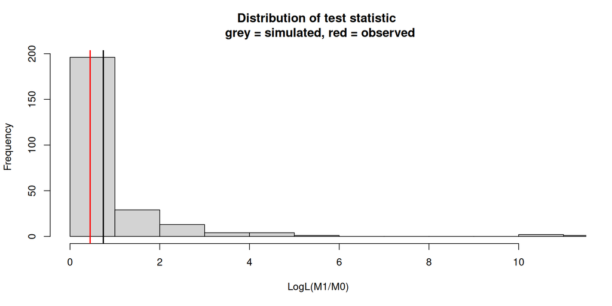

```
##
##  DHARMa simulated LRT
##
## data:  m0: reg1 m1: reg2
## LogL(M1/M0) = 0.44806, p-value = 0.348
## alternative hypothesis: M1 describes the data better than M0
```

```r
DHARMa::simulateLRT(reg1,reg2)
```

The result is the same as what we found with `anova`: the more complex model is not an improvement over the first. Such an approach by simulation is very accurate, but it can be burdensome to implement for many models, and for large datasets. Doing such simulations requires refitting the models a large number of times, and calculating the likelihood ratio every time, for the result to be accurate. GLMs generally fit pretty quickly even for moderately large datasets, but we might still want to avoid extensive comparisons by simulation.

For a single model, the `anova` function builds an analysis of deviance table; it cycles through the terms and builds an increasingly complex model. For every model it reports whether or not the improvement is statistically significant:

```r
anova(reg2)
```

```
## Analysis of Deviance Table
##
## Model: binomial, link: logit
##
## Response: y
##
## Terms added sequentially (first to last)
##
##
##       Df Deviance Resid. Df Resid. Dev  Pr(>Chi)
## NULL                     34     45.004
## x1     1   1.0632        33     43.941    0.3025
## x2     1  18.3970        32     25.544 1.793e-05 ***
## x1:x2  1   0.8961        31     24.648    0.3438
## ---
## Signif. codes:  0 '***' 0.001 '**' 0.01 '*' 0.05 '.' 0.1 ' ' 1
```

We could reconstruct such a table with the simulation function from the `DHARMa` package, but we would have to do it manually: it requires going through the pairwise comparisons ourselves.

To compare how much a model is (or isn’t) an improvement over another model, we can use an $R^2$ measure of variation. There are many potential $R^2$ statistics that we can calculate, using (for example) the functions `DescTools::PseudoR2`, `glmtoolbox::adjR2`, or `MuMIn::r.squaredLR`. We here make no recommendations on which to use, but simply choose the first for demonstration:

```r
DescTools::PseudoR2(reg1)
```

```
##  McFadden
## 0.4324117
```

```r
DescTools::PseudoR2(reg2)
```

```
##  McFadden
## 0.4523237
```

# Datasets

We will use the same datasets as in the last practicals. You can find the datasets in the “data” folder of the github repository.

1. [nickel.expand](https://raw.githubusercontent.com/BertvanderVeen/GLM-workshop/refs/heads/main/data/nickel.expand.csv): Lung cancer due to nickel exposure in South Wales [Breslow and Day (1987)](https://pubmed.ncbi.nlm.nih.gov/3329634/). You can use lung cancer and nasal cancer rates as response variable
2. [dmn](https://raw.githubusercontent.com/BertvanderVeen/GLM-workshop/refs/heads/main/data/dmn.csv): de novo mutations in children [Halldorsson et al. (2019)](https://www.science.org/doi/10.1126/science.aau1043), see also [this page](https://mccoy-lab.github.io/hgv_modules/setup.html). You can use de novo mutations of father and mother as a response variable
3. [Baseball](https://raw.githubusercontent.com/BertvanderVeen/GLM-workshop/refs/heads/main/data/Baseball.csv): attendance to baseball games [Cochran 2002](https://jse.amstat.org/v10n2/datasets.cochran.html)
4. [OME]: Counts of correct identifications, used in the presentation ([MASS package](https://rdrr.io/cran/MASS/man/OME.html)). Load with `data(OME, package = "MASS")`
5. [Lizards](https://raw.githubusercontent.com/BertvanderVeen/GLM-workshop/refs/heads/main/data/lizards.csv): Lizard counts, used in the presentation, includes a count of two lizard species and multiple categorical covariates [(Schoener 1970)](https://esajournals.onlinelibrary.wiley.com/doi/10.2307/1935376)
6. [wells](https://raw.githubusercontent.com/BertvanderVeen/GLM-workshop/refs/heads/main/data/wells.csv): Water quality of contaminated wells (y vs n) in New York with variables of surrounding land use, sewer usage, and nitrate and chloride concentration [(Eckhard et al. 1989)](https://pubs.usgs.gov/publication/wri864142)

The datasets are all stored in as “.csv” files, which means that you can load them into R by using the `read.csv("...")` function. You need to replace “…” by the link of the dataset, which you can copy by right-clicking the dataset name and choosing “copy link address”.

# Part 1

The goal of this practical is to go over the models that you fitted during the last practicals (or for the multiple linear regression practical) and perform a confirmatory analysis. You can also use $R^2$ measures for supporting your conclusions.

1. To begin, can you briefly summarize (in your own words) what the difference is between confirmatory and exploratory analysis?
2. Can you calculate deviance by hand for the binomial distribution? *Hint: it is included in today’s lecture slides*
3. Formulate a hypothesis, fit two models, and use `anova` to compare them. Do you accept or reject the alternative hypothesis?
4. Use `anova` with the most complex of the two models in 3 (or an even more complex model) to get an analysis of deviance table. Then apply `car::Anova(model, type = "II")` and `car::Anova(model, type = "III")` to the same model. Do all three give the same result?

**Why don’t they give the same answer?**

The three types differ in *what each term is tested against*:

- **Type I (sequential):** terms are added one at a time in the order you wrote the formula. Each term is tested against the model without it, but *including* all terms that came before it. The result therefore depends on the order of terms in the formula.
- **Type II (marginal, no interactions):** each main effect is tested against a model that includes all other main effects, but *not* higher-order terms involving that effect. Order does not matter. This is usually the right choice when there are no interactions, or when you want to test main effects in the presence of other main effects only.
- **Type III (marginal, all terms):** each term is tested against a model that includes *all* other terms, including interactions. This means a main effect is tested while its interaction is in the model, which can give misleading results when interactions are present and the predictors are not centred.

Try reordering the predictors in your formula and applying `anova` again. Notice that the Type I results change, while Type II and III do not.

# Part 2

**Open after Part 1**

5. Compare your confirmatory results to the model comparison with AIC/AICc/BIC from Practical 7 (the exploratory analysis). Do the two approaches agree on which model is “best”? Can you think of reasons why they might or might not overlap?
6. To build intuition for the procedures of confirmatory hypothesis testing, choose another dataset and repeat all steps.